# Coursework Report

*N* removed NAs: 3

*N* removed typo: 1

*N* removed <18: 30

*N* total clean: 116

| Group | *N* | *M*<sub>age</sub> | *M*<sub>rating</sub> |
| --- | --- | --- | --- |
| Control | 57 | 20.9 | 7.12 |
| Experim | 59 | 21.3 | 6.01 |

**Main analysis results**

*t*(114) = 8.55, *p* < .001

[interactive chart not shown]

[figure not shown]

[interactive chart not shown]

# Coursework Report

Analysing Data, Spring 2020

# Methods

## Participants

**Table 1 *Descriptive statistics by Condition***

| Condition | *N* | % | *M*<sub>age</sub> | *SD*<sub>age</sub> |
| --- | --- | --- | --- | --- |
| control | 57 | 49.1 | 20.9 | 2.40 |
| experimental | 59 | 50.9 | 21.3 | 2.49 |

## Design

This study attempted to answer the research question of what the impact of the colour red has on attraction. The variables in the data provided, as well as its and meaning and how it was measured is listed below:

- ID_CODE (factor)- Each participant was identified using a series of letters in order to ensure that their identity was kept anonymous.
  - AGE_YEARS (numeric)- Each participant was asked to share their age.
  - GROUPS (factor)- participants were randomly allocated to the experimental group (where the colour red was present in the photo), or the control group (where no red was seen in the photo)
  - QUESTION_1 (rating)- Participants questions about how attractive they found the man in the picture (listed below). A scale of 1 to 9 was used, 9 being very attractive.
  - QUESTION_2 (rating)- Participants questions about how attractive they found the man in the picture (listed below). A scale of 1 to 9 was used, 9 being very attractive.
  - QUESTION_3 (rating)- Participants questions about how attractive they found the man in the picture (listed below). A scale of 1 to 9 was used, 9 being very attractive.

  The design of this study was an independent measures design, or between groups as participants experienced only one of the two controls (experimental or control). Participants viewed the a picture of a relatively attractive Caucasian man in black and white with his face blurred out. The background was either red or white. Participants were then asked to rate the individual on the picture from a scale of one to 9 for these three questions:
  1. “How attractive do you think this person is?”
  2. “How pleasant is this person to look at?”
  3. “If I were to meet the person in this picture face to face, I would think he is attractive.” (Elliot et al., 2010)

  The hypothesis is that if the ratings of the experimental group are higher than the control group, then the colour red has makes individuals perceived as more attractive. We will be using the t-test to analyse the correlation of these results.

# Results

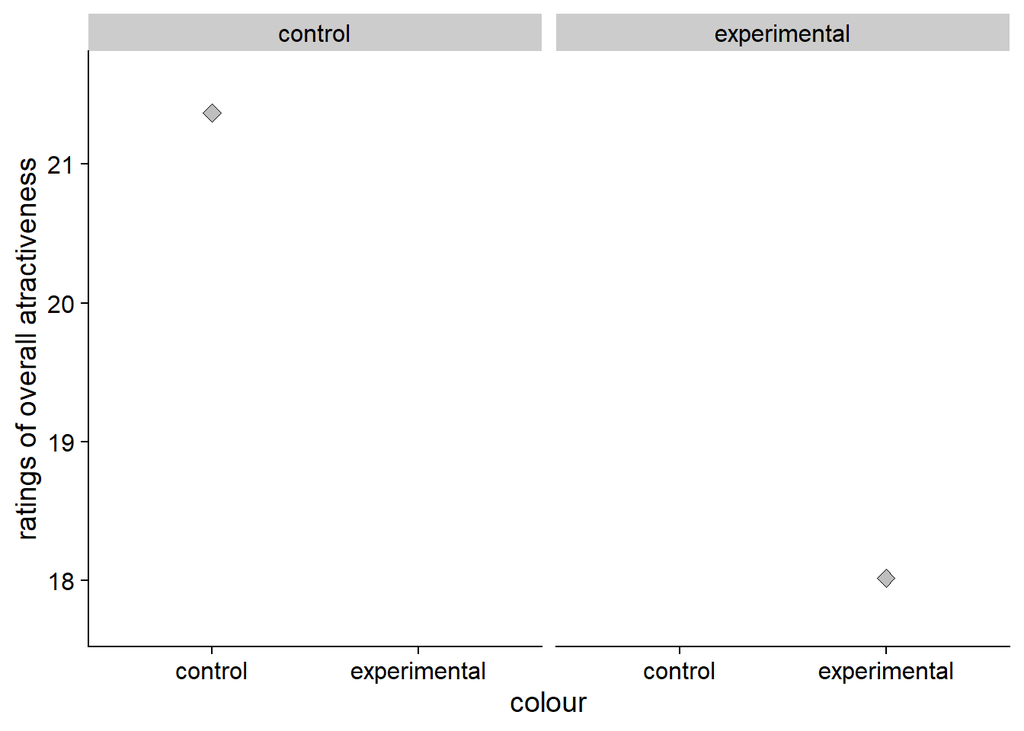

```
##
##  Pearson's product-moment correlation
##
## data:  data$QUESTION_1 and data$QUESTION_2
## t = 0.3, df = 114, p-value = 0.7
## alternative hypothesis: true correlation is not equal to 0
## 95 percent confidence interval:
##  -0.152  0.212
## sample estimates:
##   cor
## 0.031
```

# Discussion

Not only do these results go against the hypothesis, but they also go against the findings of the original study, which found that the colour red did in fact have improve the ratings of participants (Elliot et al., 2010).

Of course, further research should be done to both support the above findings, but also challenge them in order to come to a more conclusive answer. However, the implication of these findings indicate that there must be more variables, other than colour, at play in attraction. This would make sense, as many variables come to mind when one thinks of what makes someone attractive. Some examples could be facial structure, personality, etc. These ideas may be just as difficult to test as colour, but may appear more influential (Hesslinger et al., 2015). However, the results of Elliot et al (2010) make the implication of this study blurry, bringing us back to the original question: what impact does the colour have on attraction?

Replications of this study have in fact been made. Some replications have in fact continued to support the original study (Francis, 2013). Interestingly, most of these replications involved the researcher of the original study (Elliot et al., 2010). That being said, when an outside party attempted to do an experiment similar to this one, only with more ecological validity, their results do not support their hypotheses (Peperkoorn et al., 2016). There are many studies that disagree with the findings of Elliot et al (2010) (Francis, 2013; Hesslinger et al., 2015; Peperkoorn et al., 2016).

This study has many strengths. Firstly, participants were all female, in order to get a more accurate finding on the effect of red on women. Next, the researcher was able to eliminate the influence of all other colours by making the results black and white. Lastly, the researcher provided a series of questions in order to get a more rounded answer. There were also mention of the colour red when the experiment was acted out, meaning that the true purpose of this study was hidden from participants until the end. Therefore, their answers may not have been affected by response bias.

However, with every positive comes its negative. Testing the influence of colour in regard to attraction can be a difficult task. Firstly, this study is artificial due to the fact that participants were asked to rate the picture of a black and white man. Participants may have given a completely different answer if they saw the man in person (Hesslinger et al., 2015). Next, the experiment used only female participants, which means the generalisability is lowered to half the population. Also, this experiment does not discuss the influence of red in LGBTQ+ society. These communities should be tested as well to see whether the colour has more of an impact there. Another experiment should be made from the male perspective. Furthermore, the fact that participants were asked to rating the attractiveness of an individual, which means the data was self-report, which promotes response bias.

# References

Elliot, A. J., Niesta Kayser, D., Greitemeyer, T., Lichtenfeld, S., Gramzow, R. H., Maier, M. A., & Liu, H. (2010). Red, rank, and romance in women viewing men. *Journal of Experimental Psychology: General*, 139(3), 399.

Francis, G. (2013). *Publication bias in “Red, rank, and romance in women viewing men,” by Elliot et al.(2010)*.

Hesslinger, V. M., Goldbach, L., & Carbon, C.-C. (2015). Men in red: A reexamination of the red-attractiveness effect. *Psychonomic Bulletin & Review*, 22(4), 1142–1148.

Peperkoorn, L. S., Roberts, S. C., & Pollet, T. V. (2016). Revisiting the red effect on attractiveness and sexual receptivity: No effect of the color red on human mate preferences. *Evolutionary Psychology*, 14(4), 1474704916673841.